# Homegrown Data Science - Phase 2 Month 2 project

Caio Costa

11/27/2017

# Question 1

Have total emissions from PM2.5 decreased in the United States from 1999 to 2008? Using the base plotting system, make a plot showing the total PM2.5 emission from all sources for each of the years 1999, 2002, 2005, and 2008.

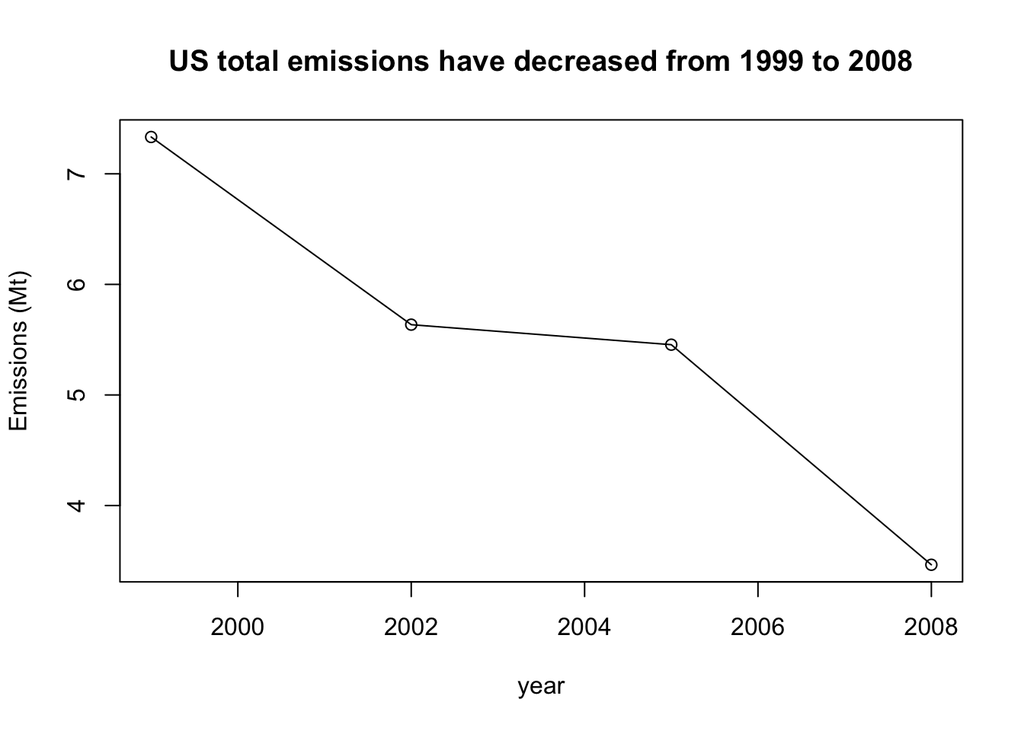

```r
emissions_by_year <- NEI %>%
  group_by(year) %>%
  summarize(Emissions = sum(Emissions)/1000000)
plot(emissions_by_year, ylab = "Emissions (Mt)")
lines(emissions_by_year)
title("US total emissions have decreased from 1999 to 2008")
```

Yes, emissions have decreased from 1999 to 2008

#Question 2

Have total emissions from PM2.5 decreased in the Baltimore City, Maryland (𝚏𝚒𝚙𝚜 == “𝟸𝟺𝟻𝟷𝟶”) from 1999 to 2008? Use the base plotting system to make a plot answering this question.

Who cares about Baltimore city?

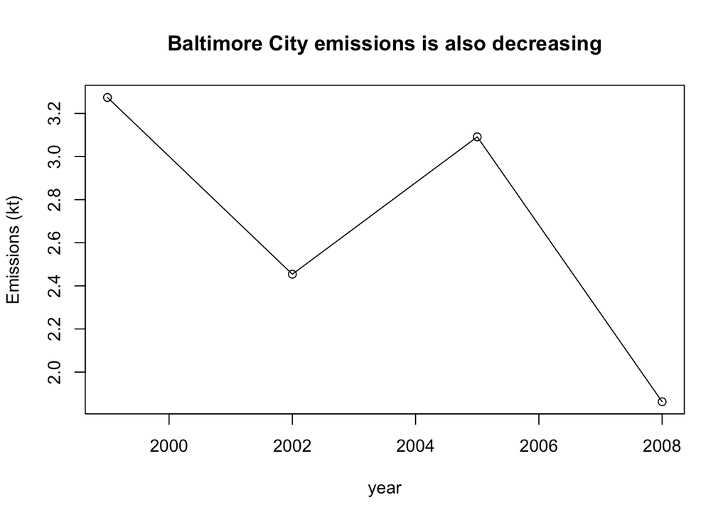

```r
emissions_by_year <- NEI %>%
  filter(fips == "24510") %>%
  group_by(year) %>%
  summarize(Emissions = sum(Emissions)/1000)
plot(emissions_by_year, ylab = "Emissions (kt)")
lines(emissions_by_year)
title("Baltimore City emissions is also decreasing")
```

Yes it have, but not before spiking on 2005

# Question 3

Of the four types of sources indicated by the 𝚝𝚢𝚙𝚎 (point, nonpoint, onroad, nonroad) variable, which of these four sources have seen decreases in emissions from 1999–2008 for Baltimore City? Which have seen increases in emissions from 1999–2008? Use the ggplot2 plotting system to make a plot answer this question.

Are there cars in Baltimore city?

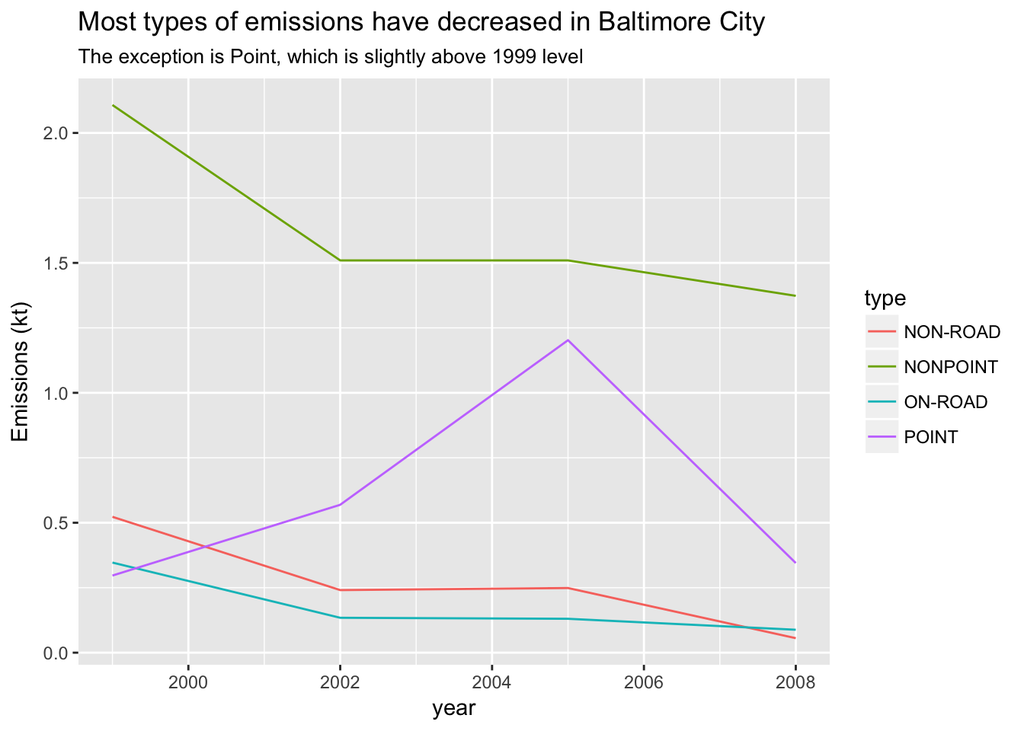

```r
NEI %>%
  filter(fips == "24510") %>%
  group_by(year,type) %>%
  summarize(Emissions = sum(Emissions)/1000) %>%
  ggplot(aes(x = year, y = Emissions)) +
  geom_line(aes(color = type)) +
  labs(title = "Most types of emissions have decreased in Baltimore City",
       subtitle = "The exception is Point, which is slightly above 1999 level",
       y = "Emissions (kt)")
```

# Question 4

Across the United States, how have emissions from coal combustion-related sources changed from 1999–2008?

For this question, I considered coal combustion-related sources the following EI Sector categories:

- Fuel Comb - Comm/Institutional - Coal
- Fuel Comb - Electric Generation - Coal
- Fuel Comb - Industrial Boilers, ICEs - Coal

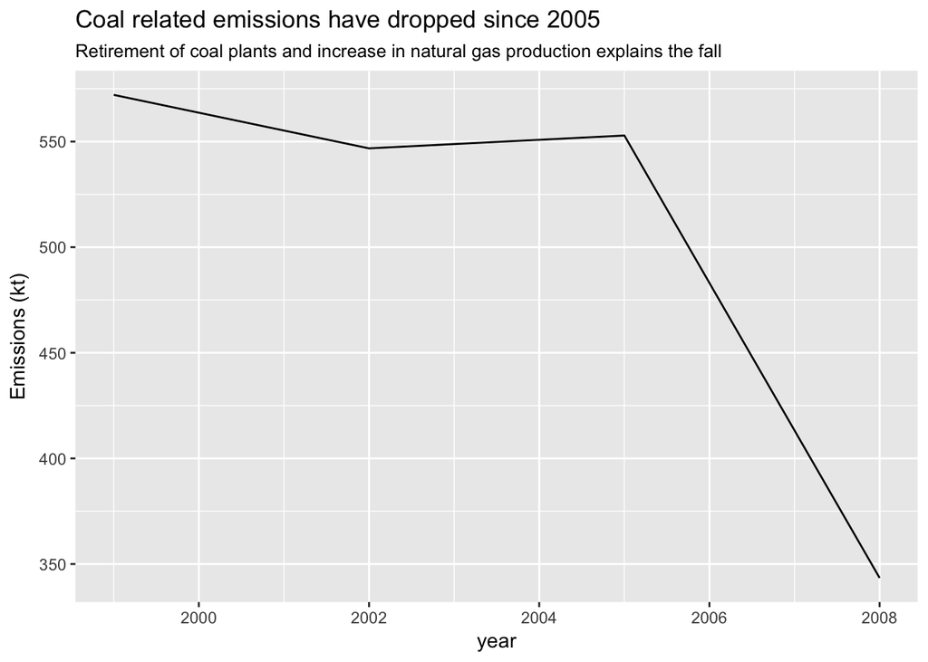

```r
NEI %>%
  left_join(SCC, by = c("SCC","SCC")) %>%
  filter(EI.Sector %in% c("Fuel Comb - Comm/Institutional - Coal", "Fuel Comb - Electric Generation - Coal", "Fuel Comb - Industrial Boilers, ICEs - Coal")) %>%
  group_by(year) %>%
  summarize(Emissions = sum(Emissions)/1000) %>%
  ggplot(aes(x = year, y = Emissions)) +
  geom_line() +
  labs(title = "Coal related emissions have dropped since 2005",
       subtitle = "Retirement of coal plants and increase in natural gas production explains the fall",
       y = "Emissions (kt)")
```

# Question 5

How have emissions from motor vehicle sources changed from 1999–2008 in Baltimore City?

For this I considered SCC Level Two categories:

- Highway Vehicles - Gasoline
- Highway Vehicles - Diesel
- Off-highway Vehicle Diesel
- Off-highway Vehicle Gasoline, 2-Stroke
- Off-highway Vehicle Gasoline, 4-Stroke

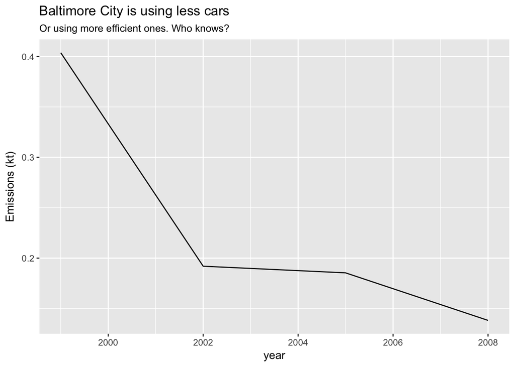

```r
NEI %>%
  left_join(SCC, by = c("SCC","SCC")) %>%
  filter(SCC.Level.Two %in% c("Highway Vehicles - Gasoline",
                              "Highway Vehicles - Diesel",
                              "Off-highway Vehicle Diesel",
                              "Off-highway Vehicle Gasoline, 2-Stroke",
                              "Off-highway Vehicle Gasoline, 4-Stroke")) %>%
  filter(fips == "24510") %>%
  group_by(year) %>%
  summarize(Emissions = sum(Emissions)/1000) %>%
  ggplot(aes(x = year, y = Emissions)) +
  geom_line() +
  labs(title = "Baltimore City is using less cars",
       subtitle = "Or using more efficient ones. Who knows?",
       y = "Emissions (kt)")
```

# Question 6

Compare emissions from motor vehicle sources in Baltimore City with emissions from motor vehicle sources in Los Angeles County, California (𝚏𝚒𝚙𝚜 == “𝟶𝟼𝟶𝟹𝟽”). Which city has seen greater changes over time in motor vehicle emissions?

We already know way too much about Baltimore City at this point. Let’s take a look at LA.

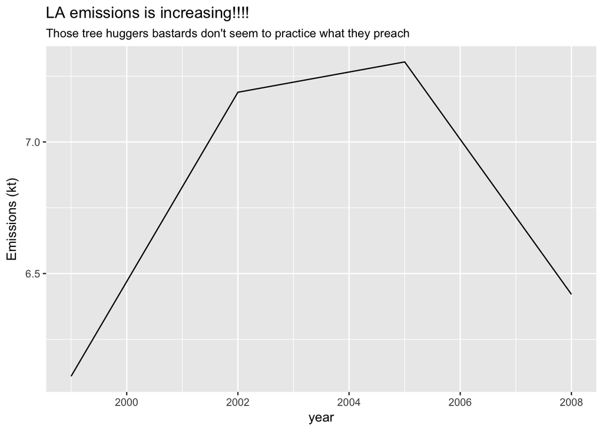

```r
NEI %>%
  left_join(SCC, by = c("SCC","SCC")) %>%
  filter(SCC.Level.Two %in% c("Highway Vehicles - Gasoline",
                              "Highway Vehicles - Diesel",
                              "Off-highway Vehicle Diesel",
                              "Off-highway Vehicle Gasoline, 2-Stroke",
                              "Off-highway Vehicle Gasoline, 4-Stroke")) %>%
  filter(fips == "06037") %>%
  group_by(year) %>%
  summarize(Emissions = sum(Emissions)/1000) %>%
  ggplot(aes(x = year, y = Emissions)) +
  geom_line() +
  labs(title = "LA emissions is increasing!!!!",
       subtitle = "Those tree huggers bastards don't seem to practice what they preach",
       y = "Emissions (kt)")
```

Let’s compare in % terms

```r
NEI %>%
  left_join(SCC, by = c("SCC","SCC")) %>%
  filter(SCC.Level.Two %in% c("Highway Vehicles - Gasoline",
                              "Highway Vehicles - Diesel",
                              "Off-highway Vehicle Diesel",
                              "Off-highway Vehicle Gasoline, 2-Stroke",
                              "Off-highway Vehicle Gasoline, 4-Stroke")) %>%
  filter(fips %in% c("24510","06037")) %>%
  group_by(year,fips) %>%
  summarize(Emissions = sum(Emissions)/1000) %>%
  spread(key = year, value = Emissions) %>%
  mutate(diff = (`2008` - `1999`)/`1999`) %>%
  select(fips,diff)
```

```
## # A tibble: 2 x 2
##    fips        diff
##   <chr>       <dbl>
## 1 06037  0.05095627
## 2 24510 -0.65762647
```

Voilà! While L.A. increased emissions by 5%, Baltimore City decreased by 66%! Baltimore City is the MVP. Shame on you L.A.